# Cross-Cohort Cell-Cell Communication in Breast Cancer

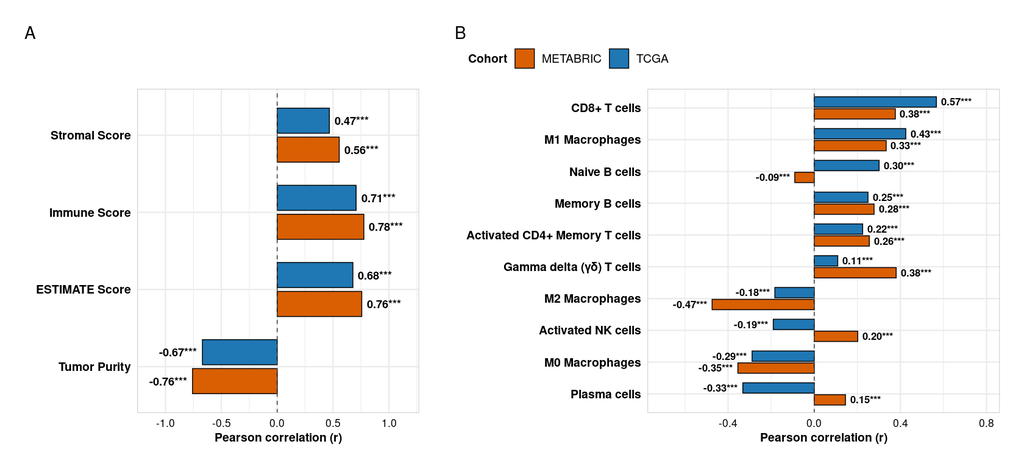

Figure 88: Correlation of the CCL5-ACKR1 co-expression score with ESTIMATE scores (A) and with the ten CIBERSORT immune subsets that correlate most strongly (B), in TCGA-BRCA and METABRIC. Stars mark p < 0.05, 0.01 and 0.001.

```r
deconv_plots[["ccl5_ackr1"]]
```

**MDK-LRP1**

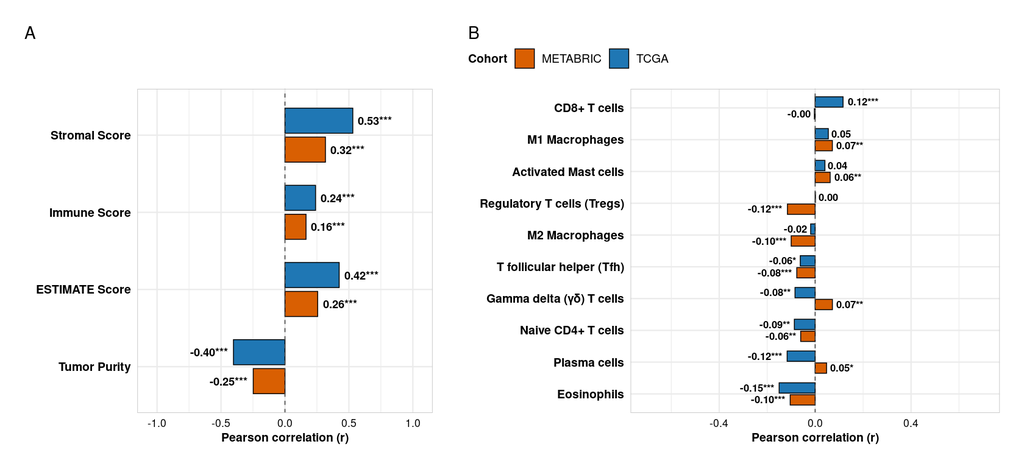

Figure 89: Correlation of the MDK-LRP1 co-expression score with ESTIMATE scores (A) and with the ten CIBERSORT immune subsets that correlate most strongly (B), in TCGA-BRCA and METABRIC. Stars mark p < 0.05, 0.01 and 0.001.

```r
deconv_plots[["mdk_lrp1"]]
```

**FN1-ITGA5/ITGB1**

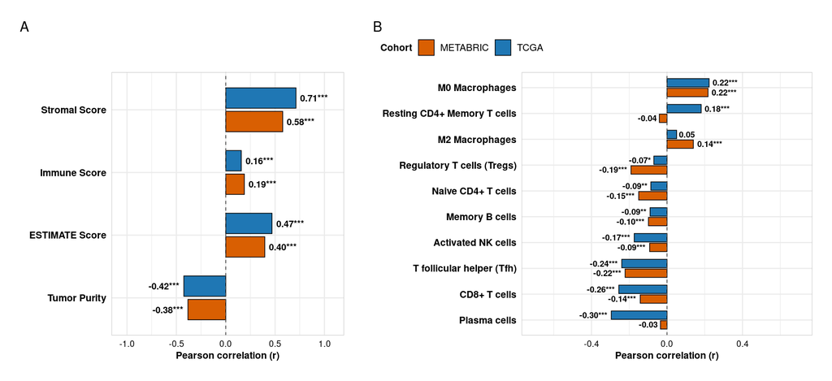

Figure 90: Correlation of the FN1-ITGA5/ITGB1 co-expression score with ESTIMATE scores (A) and with the ten CIBERSORT immune subsets that correlate most strongly (B), in TCGA-BRCA and METABRIC. Stars mark p < 0.05, 0.01 and 0.001.

```r
deconv_plots[["fn1_itga5_itgb1"]]
```

**APP-CD74**

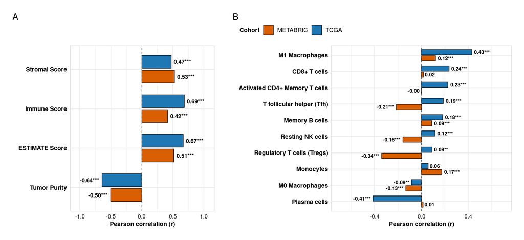

Figure 91: Correlation of the APP-CD74 co-expression score with ESTIMATE scores (A) and with the ten CIBERSORT immune subsets that correlate most strongly (B), in TCGA-BRCA and METABRIC. Stars mark p < 0.05, 0.01 and 0.001.

```r
deconv_plots[["app_cd74"]]
```

Correlations alone are hard to compare across axes, because many of them are large and shared. The next step gives the effect sizes for all five axes in both cohorts, with 95% confidence intervals, and the partial correlation after both the axis score and the composition variable are adjusted for ESTIMATE tumor purity. We interpret the correlations by their size and not by p: below 0.1 is negligible, 0.1 to 0.3 small, 0.3 to 0.5 moderate and above 0.5 large.

```r
estimate_features <- c(stromal_score = "Stromal Score", immune_score = "Immune Score", ESTIMATEScore = "ESTIMATE Score", TumorPurity = "Tumor Purity")
cib_features <- c(
  "B cell naive", "B cell memory", "B cell plasma", "T cell CD8+", "T cell CD4+ naive", "T cell CD4+ memory resting",
  "T cell CD4+ memory activated", "T cell follicular helper", "T cell regulatory (Tregs)", "T cell gamma delta",
  "NK cell resting", "NK cell activated", "Monocyte", "Macrophage M0", "Macrophage M1", "Macrophage M2",
  "Myeloid dendritic cell resting", "Myeloid dendritic cell activated", "Mast cell resting", "Mast cell activated",
  "Eosinophil", "Neutrophil"
)

deconv_rows <- list()
for (coh in names(cohort_data)) {
  d <- cohort_data[[coh]]
  for (i in seq_len(nrow(candidate_registry))) {
    score <- (d[[candidate_registry$ligand[i]]] + d[[candidate_registry$receptor[i]]]) / 2
    score_res <- resid(lm(score ~ d$TumorPurity))
    for (feat in c(names(estimate_features), cib_features)) {
      x <- as.numeric(d[[feat]])
      ct <- cor.test(score, x)
      partial_r <- if (feat %in% c("TumorPurity", "ESTIMATEScore")) NA_real_ else cor(score_res, resid(lm(x ~ d$TumorPurity)))
      deconv_rows[[length(deconv_rows) + 1]] <- data.frame(
        cohort = coh, axis_id = candidate_registry$axis_id[i], feature = feat,
        type = ifelse(feat %in% names(estimate_features), "ESTIMATE", "CIBERSORT"),
        r = unname(ct$estimate), r_lo = ct$conf.int[1], r_hi = ct$conf.int[2], p = ct$p.value, partial_r_purity = partial_r
      )
    }
  }
}
deconv <- bind_rows(deconv_rows) %>%
  mutate(
    feature_label = ifelse(feature %in% names(estimate_features), estimate_features[feature], feature),
    magnitude = cut(abs(r), c(-Inf, 0.1, 0.3, 0.5, Inf), labels = c("negligible", "small", "moderate", "large"), right = FALSE)
  )
write_csv(deconv, "results/revision/deconvolution_effect_sizes.csv")
```

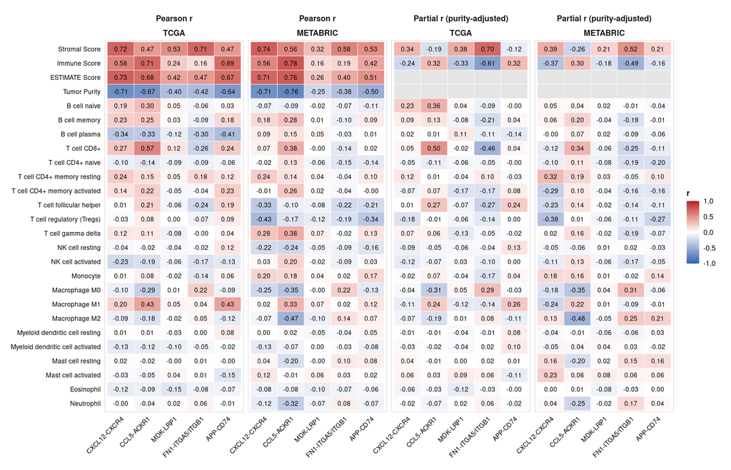

Figure 92: Correlation of each axis score with tumor composition. Left, Pearson r; right, partial r adjusted for ESTIMATE tumor purity. Rows are ESTIMATE scores and LM22 immune subsets.

```r
feature_order <- sub("Tumour", "Tumor", c(unname(estimate_features), cib_features))
deconv_long <- deconv %>%
  mutate(feature_label = sub("Tumour", "Tumor", feature_label)) %>%
  select(cohort, axis_id, feature_label, r, partial_r_purity) %>%
  tidyr::pivot_longer(c(r, partial_r_purity), names_to = "measure", values_to = "value") %>%
  mutate(
    measure = recode(measure, r = "Pearson r", partial_r_purity = "Partial r (purity-adjusted)"),
    measure = factor(measure, levels = c("Pearson r", "Partial r (purity-adjusted)")),
    Axis = factor(axis_labels[axis_id], levels = axis_labels),
    feature_label = factor(feature_label, levels = rev(feature_order)),
    cohort = factor(cohort, levels = c("TCGA", "METABRIC"))
  )
p_deconv <- ggplot(deconv_long, aes(x = Axis, y = feature_label, fill = value)) +
  geom_tile(color = "white") +
  geom_text(aes(label = ifelse(is.na(value), "", sprintf("%.2f", value))), size = 3.1) +
  facet_grid(~ measure + cohort) +
  scale_fill_gradient2(low = "#2166AC", mid = "white", high = "#B2182B", midpoint = 0, limits = c(-1, 1), na.value = "grey90", name = "r") +
  labs(x = NULL, y = NULL) +
  theme_publication() +
  theme(axis.text.x = element_text(angle = 45, hjust = 1, size = 9), axis.text.y = element_text(size = 9), panel.grid = element_blank())
ggsave("results/revision/fig_deconvolution_effect_sizes.png", p_deconv, width = 14, height = 9, dpi = 300)
p_deconv
```

```r
knitr::kable(
  deconv %>% filter(feature %in% c("T cell CD8+", "Macrophage M2", "immune_score", "stromal_score", "TumorPurity")) %>%
    transmute(feature_label, Axis = axis_labels[axis_id], cohort, r = sprintf("%.2f (%.2f to %.2f)", r, r_lo, r_hi),
              partial = round(partial_r_purity, 2), magnitude) %>%
    arrange(feature_label, cohort, Axis),
  caption = "Key deconvolution effect sizes (Pearson r with 95% CI; partial r adjusted for purity)"
)
```

Key deconvolution effect sizes (Pearson r with 95% CI; partial r adjusted for purity)

| feature_label | Axis | cohort | r | partial | magnitude |
| --- | --- | --- | --- | --- | --- |
| Immune Score | APP-CD74 | METABRIC | 0.42 (0.38 to 0.45) | -0.16 | moderate |
| Immune Score | CCL5-ACKR1 | METABRIC | 0.78 (0.76 to 0.79) | 0.30 | large |
| Immune Score | CXCL12-CXCR4 | METABRIC | 0.56 (0.53 to 0.59) | -0.37 | large |
| Immune Score | FN1-ITGA5/ITGB1 | METABRIC | 0.19 (0.15 to 0.23) | -0.49 | small |
| Immune Score | MDK-LRP1 | METABRIC | 0.16 (0.12 to 0.21) | -0.18 | small |
| Immune Score | APP-CD74 | TCGA | 0.69 (0.65 to 0.72) | 0.32 | large |
| Immune Score | CCL5-ACKR1 | TCGA | 0.71 (0.68 to 0.74) | 0.32 | large |
| Immune Score | CXCL12-CXCR4 | TCGA | 0.58 (0.54 to 0.62) | -0.24 | large |
| Immune Score | FN1-ITGA5/ITGB1 | TCGA | 0.16 (0.10 to 0.22) | -0.61 | small |
| Immune Score | MDK-LRP1 | TCGA | 0.24 (0.18 to 0.29) | -0.33 | small |
| Macrophage M2 | APP-CD74 | METABRIC | 0.07 (0.02 to 0.11) | 0.21 | negligible |
| Macrophage M2 | CCL5-ACKR1 | METABRIC | -0.47 (-0.51 to -0.44) | -0.48 | moderate |
| Macrophage M2 | CXCL12-CXCR4 | METABRIC | -0.07 (-0.11 to -0.02) | 0.13 | negligible |
| Macrophage M2 | FN1-ITGA5/ITGB1 | METABRIC | 0.14 (0.10 to 0.18) | 0.25 | small |
| Macrophage M2 | MDK-LRP1 | METABRIC | -0.10 (-0.14 to -0.06) | -0.05 | negligible |
| Macrophage M2 | APP-CD74 | TCGA | -0.12 (-0.18 to -0.06) | -0.11 | small |
| Macrophage M2 | CCL5-ACKR1 | TCGA | -0.18 (-0.24 to -0.12) | -0.19 | small |
| Macrophage M2 | CXCL12-CXCR4 | TCGA | -0.09 (-0.15 to -0.03) | -0.07 | negligible |
| Macrophage M2 | FN1-ITGA5/ITGB1 | TCGA | 0.05 (-0.01 to 0.11) | 0.08 | negligible |
| Macrophage M2 | MDK-LRP1 | TCGA | -0.02 (-0.08 to 0.04) | 0.01 | negligible |
| Stromal Score | APP-CD74 | METABRIC | 0.53 (0.49 to 0.56) | 0.21 | large |
| Stromal Score | CCL5-ACKR1 | METABRIC | 0.56 (0.52 to 0.59) | -0.26 | large |
| Stromal Score | CXCL12-CXCR4 | METABRIC | 0.74 (0.72 to 0.76) | 0.39 | large |
| Stromal Score | FN1-ITGA5/ITGB1 | METABRIC | 0.58 (0.55 to 0.61) | 0.52 | large |
| Stromal Score | MDK-LRP1 | METABRIC | 0.32 (0.28 to 0.36) | 0.21 | moderate |
| Stromal Score | APP-CD74 | TCGA | 0.47 (0.43 to 0.52) | -0.12 | moderate |
| Stromal Score | CCL5-ACKR1 | TCGA | 0.47 (0.42 to 0.51) | -0.19 | moderate |
| Stromal Score | CXCL12-CXCR4 | TCGA | 0.72 (0.69 to 0.75) | 0.34 | large |
| Stromal Score | FN1-ITGA5/ITGB1 | TCGA | 0.71 (0.68 to 0.74) | 0.70 | large |
| Stromal Score | MDK-LRP1 | TCGA | 0.53 (0.49 to 0.57) | 0.38 | large |
| T cell CD8+ | APP-CD74 | METABRIC | 0.02 (-0.03 to 0.06) | -0.11 | negligible |
| T cell CD8+ | CCL5-ACKR1 | METABRIC | 0.38 (0.34 to 0.41) | 0.34 | moderate |
| T cell CD8+ | CXCL12-CXCR4 | METABRIC | 0.07 (0.02 to 0.11) | -0.12 | negligible |
| T cell CD8+ | FN1-ITGA5/ITGB1 | METABRIC | -0.14 (-0.18 to -0.10) | -0.25 | small |
| T cell CD8+ | MDK-LRP1 | METABRIC | -0.00 (-0.05 to 0.04) | -0.06 | negligible |
| T cell CD8+ | APP-CD74 | TCGA | 0.24 (0.18 to 0.29) | 0.04 | small |
| T cell CD8+ | CCL5-ACKR1 | TCGA | 0.57 (0.53 to 0.61) | 0.50 | large |
| T cell CD8+ | CXCL12-CXCR4 | TCGA | 0.27 (0.21 to 0.32) | 0.05 | small |
| T cell CD8+ | FN1-ITGA5/ITGB1 | TCGA | -0.26 (-0.31 to -0.20) | -0.46 | small |
| T cell CD8+ | MDK-LRP1 | TCGA | 0.12 (0.06 to 0.17) | -0.02 | small |
| Tumor Purity | APP-CD74 | METABRIC | -0.50 (-0.54 to -0.47) | NA | large |
| Tumor Purity | CCL5-ACKR1 | METABRIC | -0.76 (-0.78 to -0.74) | NA | large |
| Tumor Purity | CXCL12-CXCR4 | METABRIC | -0.71 (-0.73 to -0.68) | NA | large |
| Tumor Purity | FN1-ITGA5/ITGB1 | METABRIC | -0.38 (-0.42 to -0.34) | NA | moderate |
| Tumor Purity | MDK-LRP1 | METABRIC | -0.25 (-0.29 to -0.21) | NA | small |
| Tumor Purity | APP-CD74 | TCGA | -0.64 (-0.68 to -0.61) | NA | large |
| Tumor Purity | CCL5-ACKR1 | TCGA | -0.67 (-0.70 to -0.63) | NA | large |
| Tumor Purity | CXCL12-CXCR4 | TCGA | -0.71 (-0.74 to -0.68) | NA | large |
| Tumor Purity | FN1-ITGA5/ITGB1 | TCGA | -0.42 (-0.47 to -0.37) | NA | moderate |
| Tumor Purity | MDK-LRP1 | TCGA | -0.40 (-0.45 to -0.35) | NA | moderate |

We read this as an opposing pattern in the CD8+ T-cell fraction and in stromal content: the CCL5-ACKR1 co-expression score marks T-cell-rich tumors and the FN1-ITGA5/ITGB1 score marks stroma-rich, CD8+-poor tumors. That is a bulk result. We do not see T-cell exclusion around FN1-high stroma in the spatial data, so any statement about immune exclusion rests on the bulk CD8+ association alone.

# Druggability

For the five axes we query the current release of DGIdb through its GraphQL API for the eleven axis genes: DGIdb v5.0.12, queried on 2026-10-01. The raw response is saved with the release number and the query date. The drug-gene table is rebuilt only from what DGIdb returns.

```r
dgidb_raw_path <- "results/revision/dgidb_raw_response.json"
dgidb_genes <- c("CCL5", "ACKR1", "FN1", "ITGA5", "ITGB1", "CXCL12", "CXCR4", "MDK", "LRP1", "APP", "CD74")

if (!file.exists(dgidb_raw_path)) {
  gql <- sprintf(
    '{ serviceInfo { name version } genes(names: [%s]) { nodes { name conceptId interactions { drug { name conceptId approved antiNeoplastic } interactionScore interactionTypes { type directionality } sources { sourceDbName sourceDbVersion } publications { pmid } } } } }',
    paste0('"', dgidb_genes, '"', collapse = ", ")
  )
  resp <- httr::POST("https://dgidb.org/api/graphql", body = list(query = gql), encode = "json")
  dgidb_json <- jsonlite::fromJSON(httr::content(resp, as = "text", encoding = "UTF-8"), simplifyVector = FALSE)
  dgidb_json$query_date <- as.character(Sys.Date())
  writeLines(jsonlite::toJSON(dgidb_json, auto_unbox = TRUE, pretty = TRUE), dgidb_raw_path)
}
dgidb_json <- jsonlite::fromJSON(dgidb_raw_path, simplifyVector = FALSE)

dgidb_df <- bind_rows(lapply(dgidb_json$data$genes$nodes, function(g) {
  bind_rows(lapply(g$interactions, function(x) {
    data.frame(
      gene = g$name,
      drug = x$drug$name,
      drug_concept = x$drug$conceptId,
      approved = isTRUE(x$drug$approved),
      antineoplastic = isTRUE(x$drug$antiNeoplastic),
      interaction_type = paste(unique(vapply(x$interactionTypes, function(t) t$type, character(1))), collapse = "; "),
      sources = paste(unique(vapply(x$sources, function(s) paste0(s$sourceDbName, " (", s$sourceDbVersion, ")"), character(1))), collapse = "; "),
      n_sources = length(x$sources),
      pmids = paste(unique(vapply(x$publications, function(p) as.character(p$pmid), character(1))), collapse = "; "),
      interaction_score = x$interactionScore
    )
  }))
})) %>%
  mutate(interaction_type = na_if(interaction_type, "")) %>%
  arrange(gene, desc(interaction_score))
write_csv(dgidb_df, "results/revision/dgidb_interactions_all.csv")

dgidb_release <- tibble::tibble(
  Service = dgidb_json$data$serviceInfo$name,
  Version = dgidb_json$data$serviceInfo$version,
  `Query date` = dgidb_json$query_date,
  `Genes queried` = paste(dgidb_genes, collapse = ", "),
  `Interactions returned` = nrow(dgidb_df)
)
write_csv(dgidb_release, "results/revision/dgidb_release.csv")
knitr::kable(dgidb_release, caption = "DGIdb release used for the drug-gene table")
```

DGIdb release used for the drug-gene table

| Service | Version | Query date | Genes queried | Interactions returned |
| --- | --- | --- | --- | --- |
| DGIdb | v.5.0.12 | 2026-10-01 | CCL5, ACKR1, FN1, ITGA5, ITGB1, CXCL12, CXCR4, MDK, LRP1, APP, CD74 | 171 |

```r
knitr::kable(dgidb_df %>% count(gene, name = "interactions") %>% left_join(dgidb_df %>% group_by(gene) %>% summarise(approved = sum(approved), antineoplastic = sum(antineoplastic)), by = "gene"),
             caption = "DGIdb interactions per axis gene")
```

DGIdb interactions per axis gene

| gene | interactions | approved | antineoplastic |
| --- | --- | --- | --- |
| ACKR1 | 3 | 2 | 1 |
| APP | 48 | 15 | 3 |
| CCL5 | 3 | 2 | 1 |
| CD74 | 5 | 1 | 1 |
| CXCL12 | 9 | 7 | 7 |
| CXCR4 | 60 | 5 | 3 |
| FN1 | 11 | 2 | 3 |
| ITGA5 | 11 | 1 | 4 |
| ITGB1 | 17 | 2 | 3 |
| LRP1 | 3 | 1 | 0 |
| MDK | 1 | 1 | 1 |

```r
published_s5 <- tibble::tribble(
  ~gene, ~drug_published,
  "APP", "MEMANTINE",
  "APP", "DONEPEZIL",
  "CD74", "MILATUZUMAB",
  "CD74", "ST-1839",
  "FN1", "VATALANIB",
  "FN1", "VOLOCIXIMAB",
  "ITGA5", "VOLOCIXIMAB",
  "ITGA5", "ATN-161",
  "ITGB1", "OS225",
  "ACKR1", "CHLOROQUINE"
)
s5_check <- published_s5 %>%
  rowwise() %>%
  mutate(
    returned_by_dgidb = any(dgidb_df$gene == gene & grepl(drug_published, dgidb_df$drug, fixed = TRUE)),
    dgidb_sources = paste(dgidb_df$sources[dgidb_df$gene == gene & grepl(drug_published, dgidb_df$drug, fixed = TRUE)], collapse = " | "),
    same_drug_other_axis_genes = paste(setdiff(dgidb_df$gene[grepl(drug_published, dgidb_df$drug, fixed = TRUE)], gene), collapse = ", ")
  ) %>%
  ungroup()
write_csv(s5_check, "results/revision/dgidb_published_s5_check.csv")
knitr::kable(s5_check, caption = "Drug-gene pairs often cited for the axis genes, checked against the current DGIdb release")
```

Drug-gene pairs often cited for the axis genes, checked against the current DGIdb release

| gene | drug_published | returned_by_dgidb | dgidb_sources | same_drug_other_axis_genes |
| --- | --- | --- | --- | --- |
| APP | MEMANTINE | FALSE |  |  |
| APP | DONEPEZIL | FALSE |  |  |
| CD74 | MILATUZUMAB | TRUE | TdgClinicalTrial (Jan-2014); MyCancerGenome (20-Jun-2017); TTD (2020.06.01) \| GuideToPharmacology (2026.2) \| ChEMBL (37) |  |
| CD74 | ST-1839 | FALSE |  |  |
| FN1 | VATALANIB | FALSE |  |  |
| FN1 | VOLOCIXIMAB | FALSE |  | ITGA5, ITGB1 |
| ITGA5 | VOLOCIXIMAB | TRUE | GuideToPharmacology (2026.2) \| ChEMBL (37) \| TALC (12-May-2016) | ITGB1 |
| ITGA5 | ATN-161 | TRUE | ChEMBL (37) | ITGB1 |
| ITGB1 | OS225 | FALSE |  |  |
| ACKR1 | CHLOROQUINE | TRUE | TTD (2020.06.01) | APP |

```r
# One row per gene-drug name; DGIdb returns separate records for some drug concepts
s5_rebuilt <- dgidb_df %>%
  group_by(gene, drug) %>%
  summarise(
    approved = any(approved),
    antineoplastic = any(antineoplastic),
    interaction_type = paste(sort(unique(na.omit(unlist(strsplit(interaction_type, "; "))))), collapse = "; "),
    sources = paste(sort(unique(unlist(strsplit(sources, "; ")))), collapse = "; "),
    pmids = paste(sort(unique(na_if(unlist(strsplit(pmids, "; ")), ""))), collapse = "; "),
    max_interaction_score = max(interaction_score),
    .groups = "drop"
  ) %>%
  mutate(interaction_type = na_if(interaction_type, ""), pmids = na_if(pmids, "")) %>%
  arrange(gene, desc(max_interaction_score))
write_csv(s5_rebuilt, "results/revision/table_S5_rebuilt.csv")
knitr::kable(s5_rebuilt %>% filter(gene %in% c("CCL5", "ACKR1", "FN1", "ITGA5", "ITGB1")), digits = 2,
             caption = "Drug-gene table, lead-axis genes (all genes in table_S5_rebuilt.csv)")
```

Drug-gene table, lead-axis genes (all genes in table_S5_rebuilt.csv)

| gene | drug | approved | antineoplastic | interaction_type | sources | pmids | max_interaction_score |
| --- | --- | --- | --- | --- | --- | --- | --- |
| ACKR1 | AQ-13 | FALSE | FALSE | NA | TTD (2020.06.01) | NA | 17.64 |
| ACKR1 | CHLOROQUINE | TRUE | TRUE | NA | TTD (2020.06.01) | NA | 1.10 |
| ACKR1 | CLOZAPINE | TRUE | FALSE | NA | PharmGKB (20260622) | 30647433 | 0.38 |
| CCL5 | RECOMBINANT OX40 LIGAND | FALSE | FALSE | NA | NCI (14-September-2017) | 12161277 | 17.64 |
| CCL5 | FLUTICASONE | TRUE | FALSE | NA | NCI (14-September-2017) | 14556981 | 1.86 |
| CCL5 | IMATINIB | TRUE | TRUE | NA | PharmGKB (20260622) | 41193444 | 0.48 |
| FN1 | L19IL2 | FALSE | TRUE | binder | ChEMBL (37); CIViC (08-June-2026) | 24906352; 31482307 | 19.25 |
| FN1 | DAROMUN | FALSE | TRUE | NA | CIViC (08-June-2026) | 25971540 | 9.62 |
| FN1 | AS-1409 | FALSE | FALSE | binder | ChEMBL (37) | NA | 4.81 |
| FN1 | L19SIP 131I | FALSE | FALSE | other/unknown | ChEMBL (37) | NA | 4.81 |
| FN1 | L19TNFA | FALSE | FALSE | binder | ChEMBL (37) | NA | 4.81 |
| FN1 | MU-BC-1 | FALSE | FALSE | binder | ChEMBL (37) | NA | 4.81 |
| FN1 | ONFEKAFUSP ALFA | FALSE | FALSE | NA | TTD (2020.06.01) | NA | 4.81 |
| FN1 | RADRETUMAB | FALSE | FALSE | binder | ChEMBL (37) | NA | 4.81 |
| FN1 | AS1409 | FALSE | FALSE | NA | TdgClinicalTrial (Jan-2014) | NA | 1.60 |
| FN1 | DACARBAZINE | TRUE | TRUE | NA | CIViC (08-June-2026) | 31482307 | 0.64 |
| FN1 | OCRIPLASMIN | TRUE | FALSE | cleavage | ChEMBL (37); TTD (2020.06.01) | NA | 0.25 |
| ITGA5 | JSM 6427 | FALSE | FALSE | NA | TdgClinicalTrial (Jan-2014); TTD (2020.06.01) | NA | 4.81 |
| ITGA5 | PF-04605412 | FALSE | TRUE | antibody; inhibitor | ChEMBL (37); TALC (12-May-2016) | NA | 4.81 |
| ITGA5 | VOLOCIXIMAB | FALSE | TRUE | antibody; inhibitor | ChEMBL (37); GuideToPharmacology (2026.2); TALC (12-May-2016) | NA | 4.81 |
| ITGA5 | ETARACIZUMAB | FALSE | TRUE | antibody | TALC (12-May-2016) | NA | 2.41 |
| ITGA5 | RECOMBINANT MACROPHAGE COLONY-STIMULATING FACTOR | FALSE | FALSE | NA | NCI (14-September-2017) | 11061591 | 2.41 |
| ITGA5 | ATN-161 | FALSE | FALSE | inhibitor | ChEMBL (37) | NA | 1.20 |
| ITGA5 | CILENGITIDE | FALSE | TRUE | NA | TdgClinicalTrial (Jan-2014) | NA | 0.96 |
| ITGA5 | INTEGRIN RECEPTOR ANTAGONIST GLPG0187 | FALSE | FALSE | NA | TdgClinicalTrial (Jan-2014) | NA | 0.80 |
| ITGA5 | DIMETHYL SULFOXIDE | TRUE | FALSE | NA | NCI (14-September-2017) | 9678720 | 0.60 |
| ITGB1 | JSM 6427 | FALSE | FALSE | NA | TdgClinicalTrial (Jan-2014); TTD (2020.06.01) | NA | 3.11 |
| ITGB1 | VOLOCIXIMAB | FALSE | TRUE | antibody; inhibitor | ChEMBL (37); TALC (12-May-2016); TdgClinicalTrial (Jan-2014) | NA | 2.08 |
| ITGB1 | ATL1102 | FALSE | FALSE | NA | TdgClinicalTrial (Jan-2014) | NA | 1.56 |
| ITGB1 | ETARACIZUMAB | FALSE | TRUE | antibody | TALC (12-May-2016) | NA | 1.56 |
| ITGB1 | FIRATEGRAST | FALSE | FALSE | inhibitor | ChEMBL (37); TdgClinicalTrial (Jan-2014) | NA | 1.56 |
| ITGB1 | PF-04605412 | FALSE | TRUE | antibody | TALC (12-May-2016) | NA | 1.56 |
| ITGB1 | RG-7594 | FALSE | FALSE | binder | ChEMBL (37) | NA | 1.56 |
| ITGB1 | SAN-300 | FALSE | FALSE | NA | TdgClinicalTrial (Jan-2014) | NA | 1.56 |
| ITGB1 | NATALIZUMAB | TRUE | FALSE | inhibitor | ChEMBL (37) | NA | 1.04 |
| ITGB1 | R1295 | FALSE | FALSE | NA | TdgClinicalTrial (Jan-2014) | NA | 1.04 |
| ITGB1 | ATN-161 | FALSE | FALSE | inhibitor | ChEMBL (37) | NA | 0.78 |
| ITGB1 | COMPOUND 7 [PMID: 31381331] | FALSE | FALSE | inhibitor | GuideToPharmacology (2026.2) | NA | 0.62 |
| ITGB1 | ABITUZUMAB | FALSE | FALSE | inhibitor | ChEMBL (37) | NA | 0.52 |
| ITGB1 | INTEGRIN RECEPTOR ANTAGONIST GLPG0187 | FALSE | FALSE | NA | TdgClinicalTrial (Jan-2014) | NA | 0.52 |
| ITGB1 | ANTI-THYMOCYTE GLOBULIN | TRUE | FALSE | NA | TdgClinicalTrial (Jan-2014) | NA | 0.28 |

```r
DT::datatable(dgidb_df, filter = "top", rownames = FALSE, options = list(pageLength = 15, scrollX = TRUE),
              caption = "All DGIdb interactions for the axis genes (current release)")
```

| gene | drug | drug_concept | approved | antineoplastic | interaction_type | sources | n_sources | pmids | interaction_score |
| --- | --- | --- | --- | --- | --- | --- | --- | --- | --- |
| ACKR1 | AQ-13 | drugbank:DB17749 | False | False |  | TTD (2020.06.01) | 1 |  | 17.644 |
| ACKR1 | CHLOROQUINE | rxcui:2393 | True | True |  | TTD (2020.06.01) | 1 |  | 1.1027 |
| ACKR1 | CLOZAPINE | rxcui:2626 | True | False |  | PharmGKB (20260622) | 1 | 30647433 | 0.3836 |
| APP | VALILTRAMIPROSATE | chembl:CHEMBL4650301 | False | False | modulator | TdgClinicalTrial (Jan-2014); TTD (2020.06.01); ChEMBL (37) | 3 |  | 3.3082 |
| APP | GSK933776 | chembl:CHEMBL2109300 | False | False | binder | TTD (2020.06.01); ChEMBL (37) | 2 | 20497044 | 3.3082 |
| APP | VANUTIDE CRIDIFICAR | chembl:CHEMBL2108058 | False | False | vaccine | TdgClinicalTrial (Jan-2014); ChEMBL (37) | 2 |  | 2.2055 |
| APP | TRAMIPROSATE | rxcui:1374845 | False | False |  | TdgClinicalTrial (Jan-2014); TTD (2020.06.01) | 2 |  | 2.2055 |
| APP | CHEMBL:CHEMBL177126 | chembl:CHEMBL177126 | False | False |  | DTC (2020-09-02) | 1 | 22921742 | 2.2055 |
| APP | FERULATE | chembl:CHEMBL32749 | False | False |  | DTC (2020-09-02) | 1 | 24076170 | 2.2055 |
| APP | LECANEMAB | iuphar.ligand:12202 | False | False |  | TdgClinicalTrial (Jan-2014); TTD (2020.06.01) | 2 |  | 2.2055 |

[output cut: 161 more lines]

# Summary

We integrated three single-cell cohorts of primary breast cancer (74 tumors) with two ligand-receptor frameworks and obtained a consensus of 209 interactions that are conserved across cohorts and methods. After a general rule that removes promiscuous single-chain matrix receptors, five receptor-specific axes rank first to fifth, and they stay there across 12 alternative sketches of the data. We then asked what each axis is associated with.

```r
summary_table <- tibble::tibble(axis_id = candidate_registry$axis_id) %>%
  mutate(
    Axis = axis_labels[axis_id],
    `Pooled OS, double-high (TCGA + METABRIC)` = vapply(axis_id, function(a) paste0(hr_text(primary_pooled, axis_id = a), ", q = ", signif(pick(primary_pooled, "q_bh", axis_id = a), 2)), character(1)),
    `Pooled OS per SD, continuous score` = vapply(axis_id, function(a) paste0(hr_text(s4, axis_id = a), ", q = ", signif(pick(s4, "q_bh", axis_id = a), 2)), character(1)),
    `Three cohorts, continuous score` = vapply(axis_id, function(a) hr_text(pooled_3, axis_id = a, family = "C2 continuous"), character(1)),
    `FDR genes in pooled pseudobulk` = vapply(axis_id, function(a) as.character(pick(pooled_summary, "degs_fdr05", axis_id = a)), character(1))
  ) %>%
  select(-axis_id)
knitr::kable(summary_table, caption = "Evidence for the five axes in the bulk cohorts and in the pooled pseudobulk analysis.")
```

Evidence for the five axes in the bulk cohorts and in the pooled pseudobulk analysis.

| Axis | Pooled OS, double-high (TCGA + METABRIC) | Pooled OS per SD, continuous score | Three cohorts, continuous score | FDR genes in pooled pseudobulk |
| --- | --- | --- | --- | --- |
| CXCL12-CXCR4 | 0.96 (0.83-1.13), q = 0.81 | 1.02 (0.95-1.09), q = 0.55 | 1.02 (0.96-1.08) | 34 |
| CCL5-ACKR1 | 0.92 (0.79-1.07), q = 0.48 | 0.88 (0.81-0.94), q = 0.0012 | 0.88 (0.83-0.94) | 0 |
| MDK-LRP1 | 0.92 (0.79-1.07), q = 0.48 | 0.98 (0.92-1.04), q = 0.55 | 0.99 (0.94-1.05) | 0 |
| FN1-ITGA5/ITGB1 | 1.23 (1.08-1.41), q = 0.013 | 1.16 (1.08-1.23), q = 7.3e-05 | 1.16 (1.10-1.23) | 99 |
| APP-CD74 | 0.98 (0.84-1.14), q = 0.81 | 1.08 (1.01-1.15), q = 0.033 | 1.05 (0.99-1.11) | 2 |

**FN1-ITGA5/ITGB1** has the clearest adverse association with overall survival. In the primary analysis of TCGA-BRCA and METABRIC, double-high tumors have a hazard ratio of 1.23 (1.08-1.41) (BH q = 0.013), with the same direction in both cohorts and no heterogeneity. SCAN-B gives a similar estimate (1.34 (1.06-1.69), BH q = 0.065), the three cohorts together give 1.26 (1.12-1.41), and the association holds after multiple imputation, PAM50 stratification, as a continuous score and, for the continuous score, after adjustment for tumor composition; it points the same way for disease-specific survival in METABRIC (q = 0.054). In a model with both genes, FN1 carries most of the bulk signal, so the result marks a fibronectin-rich stromal and vascular state and does not show that the pairing of FN1 with α5β1 is prognostic. In single cells, FN1-high endothelium shows a basement-membrane and angiogenic remodeling program together with a reduced MHC-II program, FN1-ITGA5/ITGB1 communication is much stronger in tumors than in normal breast and is driven by fibroblast FN1, and fibroblasts and endothelial cells sit side by side in tissue, as expected for stroma. The FN1-ITGA5/ITGB1 score is the only one negatively correlated with CD8+ T-cell content in bulk tumors, but we did not see T-cell exclusion around FN1-high stroma in tissue, so immune exclusion remains a bulk observation.

**CCL5-ACKR1** is associated with better survival when scored as a continuous co-expression variable (0.88 (0.83-0.94) per SD in the three cohorts, with no heterogeneity), and the association remains after adjustment for tumor composition. The dichotomized all-patient association is null in all three cohorts and is absorbed by immune and stromal content. Its luminal subgroup does not survive correction. In tissue, T cells co-localize with ACKR1-positive venular endothelium in all six Visium sections, with co-expression in those niches, which is the strongest spatial result. In the independent HER2ST cohort the same pattern is directionally consistent and nominally significant for co-expression, and it does not meet the significance criterion, so we describe it as supportive and not as a replication. ACKR1 does not signal, so we treat the axis as a reference for T-cell entry through venules, and no gene passes FDR below 0.05 in the pooled pseudobulk contrast.

**CXCL12-CXCR4, MDK-LRP1 and APP-CD74** are null in the primary survival analysis. APP-CD74 has a continuous-score association that differs in direction between cohorts and cannot be interpreted. The spatial and pseudobulk results for these axes are exploratory.

These results are observational. Single-cell inference gives candidate interactions and not demonstrated signaling. Bulk expression cannot separate a ligand from its receptor or one cell type from another, Visium spots hold several cells, the spatial analysis rests on six sections of which four overlap with the discovery cohort, and the per-cohort pseudobulk comparisons have little power. We therefore regard the two lead axes as prioritized candidates for experimental follow-up, and not as established mechanisms or treatment targets.

# Session information

The analysis used R 4.5.1 with Seurat 5.5.0, scDblFinder 1.22.0, harmony 2.0.5, CellChat 1.6.1, LIANA 0.1.14, nichenetr 2.2.1, decoupleR 2.9.7, edgeR 4.6.3, immunedeconv 2.1.0, spacexr 2.2.1, survival 3.8.3, metafor 5.2.1 and mice 3.19.0, and Quarto 1.5.57. The R session details are printed below.